# Module 2 worksheet

```r
library(ggplot2) #loads the ggplot functions
library(ggthemes) #themes to apply to a plot
```

Scientists use plots to present their results to others and to explore potential relationships among variables in their data. Both activities are critical for enhancing the viewers comprehension of your scientific questions and results.

# Exercise 2A

## Build a scatterplot

Load the dataset called WolvesYNP.csv using the function `read.csv`.

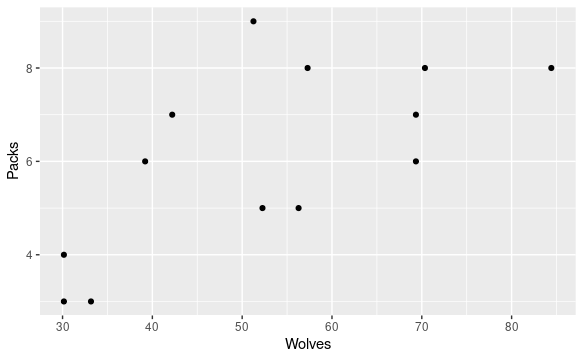

```r
wolves.dat <- read.csv(file="../Data/WolvesYNP.csv")
ggplot(data=wolves.dat, aes(x=Wolves, y=Packs)) +
  geom_point()
```

# Exercise 2B

## Polishing your scatterplot

Now let’s polish the above plot by changin the x-axis to be “Wolves in Yellowstone National Park” and the y-axis to be “Packs in Yellowstone National Park”. Another useful argument to `geom_point` is size. Try letting the aesthetic `size=Elk` and see if any patterns emerge. Finally explore adding a theme to the plot. These links have examples of default themes (https://ggplot2.tidyverse.org/reference/ggtheme.html) and themes from the ggthemes package (https://yutannihilation.github.io/allYourFigureAreBelongToUs/ggthemes/). For example if I wanted to use the `theme_linedraw` I would add `theme_linedraw()` to the existing plot. Find one you like. Based on this figure do you see any trends associated with Wolves and Packs? How about Elk and Packs?

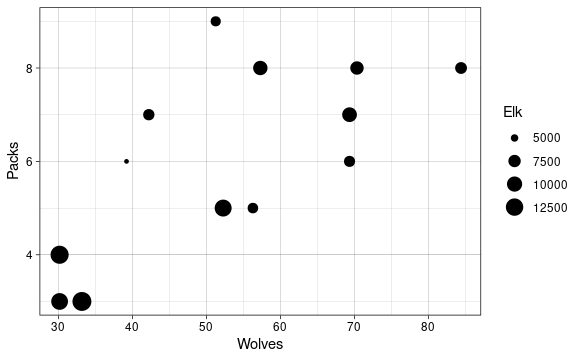

```r
wolves.dat <- read.csv(file="../Data/WolvesYNP.csv")
ggplot(data=wolves.dat, aes(x=Wolves, y=Packs, size=Elk)) +
  geom_point() + theme_linedraw()
```

# Exercise 2C

## Combining geometries

Finally, add a smoothing lines to illustrate trends in the data using `geom_smooth()`. You can use the default smoother or a linear regression.

# Excercise 2D

## Build a boxplot

Categorical data can be broken up into categories, where categories have no inherent numerical values relative to others. Examples include colors (red, green, blue) or survival (yes, no). Below we read in a dataset that describes each passenger on the Titanic and included the categorical variable `survive` and the numerical variable `age`. We will use the (somewhat macabre) dataset to build a boxplot. Read in the dataset, then build a boxplot using `geom_boxplot`. Do you see any potential differences in age between those that survived and those that didn’t?

```r
#code to estimate the profile interval
titanic.dat <- read.csv(file="../Data/titanic.csv")
```

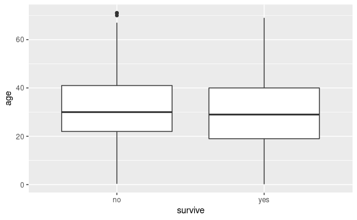

```r
ggplot(titanic.dat) +
  geom_boxplot(aes(x=survive, y=age))
```

# Excercise 2E

## Univariate plots

Histograms are univariate plots (`geom_histogram`) used to illustrate numerical variables and barcharts (`geom_bar`) are univariate plots used to illustrate categorical variables. In both of these kinds of plots we only specify the aesthetic `x` (no `y` aesthetic).

1. Build a histogram of Elk counts in Yellowstone National Park using the variable `Elk`.
2. Build a barplot from the Titanic dataset using the `embarked` variable (locations that passengers embarked from). Bonus points if you can figure out how to also get survival on the embarked plot.

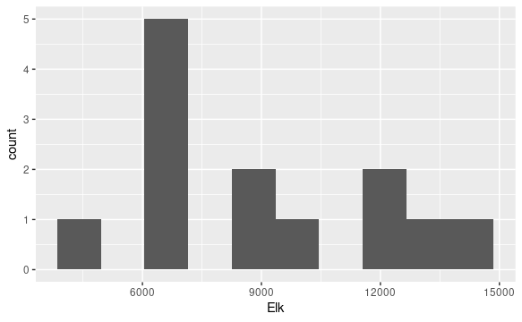

```r
ggplot(data=wolves.dat) +
  geom_histogram(aes(x=Elk), bins=10)
```

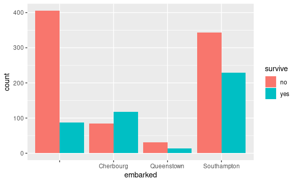

```r
ggplot(data=titanic.dat) +
  geom_bar(aes(x=embarked, fill=survive), position="dodge")
```